# Patrones de navegación y conversión: protocolo reproducible y EDA

UPeU · Ciencia de Datos e IA Aplicada · Producto de la Unidad I

Autores/as

Nolberto García Valdez

Lina Argote Lazon

Estrella Azucena Esquiagola Aranda

Mercedes Maria Nagamine Miyashiro

Jazmin Milagros Damian Ledesma

# 1. Contexto y pregunta

**Proyecto:** Patrones de navegación asociados con la conversión de compras en comercio electrónico. **Pregunta:** ¿Qué patrones de navegación se asocian con sesiones que finalizan en compra? H1: mayor actividad en productos se relaciona con compra; H2: tasas de rebote y salida menores se relacionan con compra; H3: existen correlaciones que justifican evaluar PCA. Asociación no equivale a causalidad.

# 2. Fuente, trazabilidad y ética

Datos secundarios de UCI Machine Learning Repository, dataset 468 (DOI: https://doi.org/10.24432/C5F88Q). Registros de sesiones, no de personas identificadas. No se asume consentimiento individual obtenido por el investigador ni generalización a Perú. El CSV original permanece en `data/raw`.

# 3. Auditoría de calidad

```
Sesiones: 12330 | Variables: 18 | Nulos: 0 | Filas idénticas: 125
```

```
Compra
FALSE  TRUE
10422  1908
```

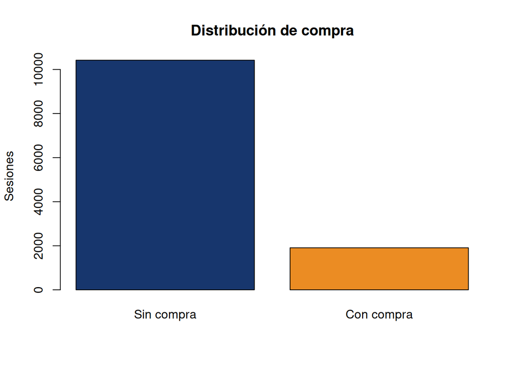

Se conservan las filas idénticas: carecemos de identificador de sesión para concluir que son errores. No se necesita imputación. Los códigos de sistema operativo, navegador, región y tráfico representan categorías.

# 4. Ingeniería de variables y PCA

La preparación íntegra y sus decisiones están documentadas en `scripts/01_preparacion.R` y `docs/diccionario_datos.xlsx`. Se generan indicadores de páginas, duración, intensidad y `log1p` de tiempos, preservando las variables originales. `PageValues` se reserva con advertencia de posible fuga temporal de información.

```
                        Administrative Administrative_Duration Informational Informational_Duration
Administrative                   1.000                   0.602         0.377                  0.256
Administrative_Duration          0.602                   1.000         0.303                  0.238
Informational                    0.377                   0.303         1.000                  0.619
Informational_Duration           0.256                   0.238         0.619                  1.000
ProductRelated                   0.431                   0.289         0.374                  0.280
ProductRelated_Duration          0.374                   0.355         0.388                  0.347
BounceRates                     -0.224                  -0.144        -0.116                 -0.074
ExitRates                       -0.316                  -0.206        -0.164                 -0.105
                        ProductRelated ProductRelated_Duration BounceRates ExitRates
Administrative                   0.431                   0.374      -0.224    -0.316
Administrative_Duration          0.289                   0.355      -0.144    -0.206
Informational                    0.374                   0.388      -0.116    -0.164
Informational_Duration           0.280                   0.347      -0.074    -0.105
ProductRelated                   1.000                   0.861      -0.205    -0.293
ProductRelated_Duration          0.861                   1.000      -0.185    -0.252
BounceRates                     -0.205                  -0.185       1.000     0.913
ExitRates                       -0.293                  -0.252       0.913     1.000
```

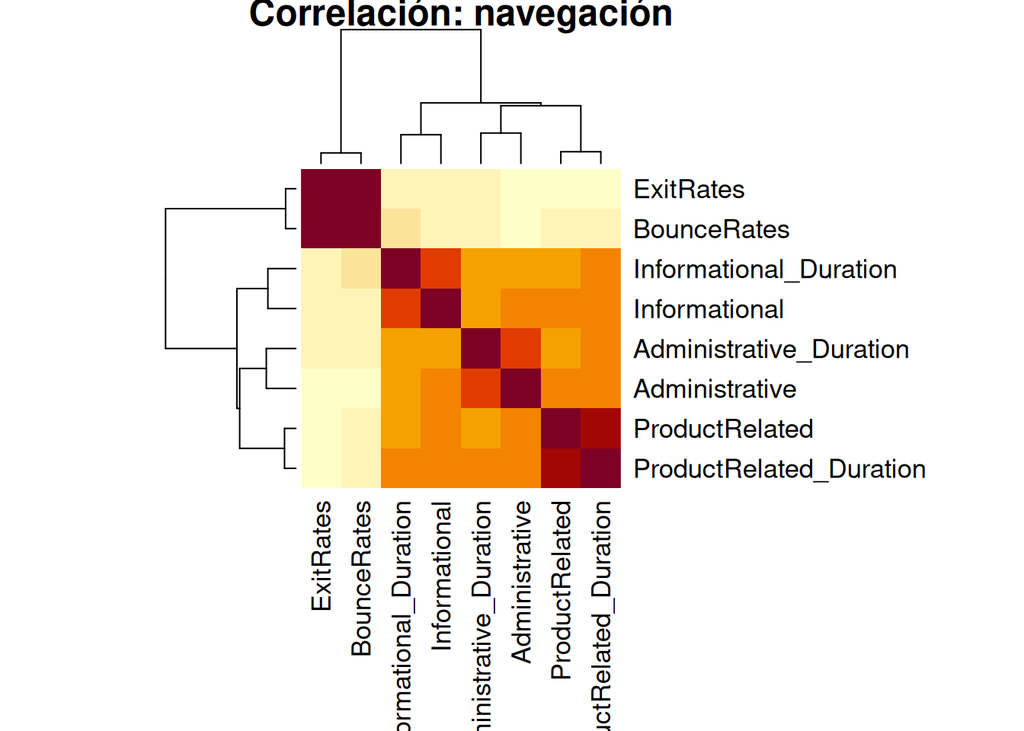

```
  PC Autovalor Varianza_pct Acumulada_pct
 PC1     3.368         42.1          42.1
 PC2     1.643         20.5          62.6
 PC3     1.017         12.7          75.4
 PC4     0.995         12.4          87.8
 PC5     0.422          5.3          93.1
 PC6     0.352          4.4          97.5
 PC7     0.123          1.5          99.0
 PC8     0.079          1.0         100.0
```

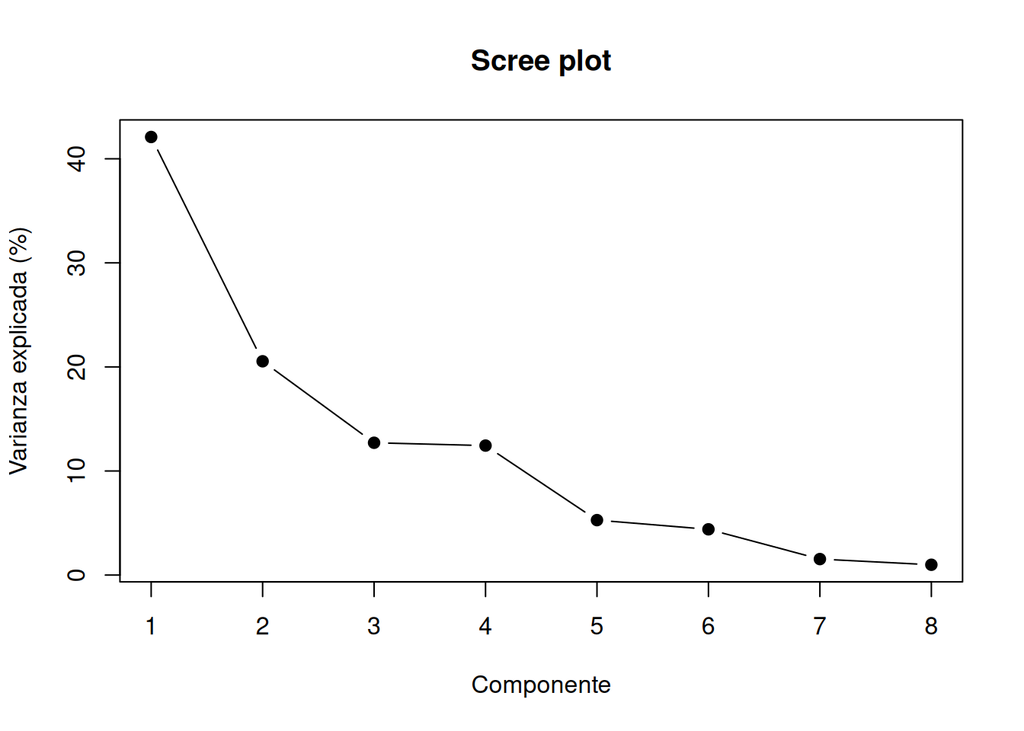

```
                           PC1   PC2
Administrative           0.384 0.050
Administrative_Duration  0.331 0.106
Informational            0.352 0.279
Informational_Duration   0.301 0.303
ProductRelated           0.417 0.127
ProductRelated_Duration  0.419 0.171
BounceRates             -0.275 0.639
ExitRates               -0.320 0.602
```

Los dos primeros componentes explican 62.6 % de la varianza, por lo que dos dimensiones NO preservan la totalidad de información. Las cargas reportadas son coeficientes de los eigenvectores (no correlaciones). El PCA es exploratorio: ningún parámetro aprendido del conjunto completo puede reutilizarse en la validación cruzada de Unidad II.

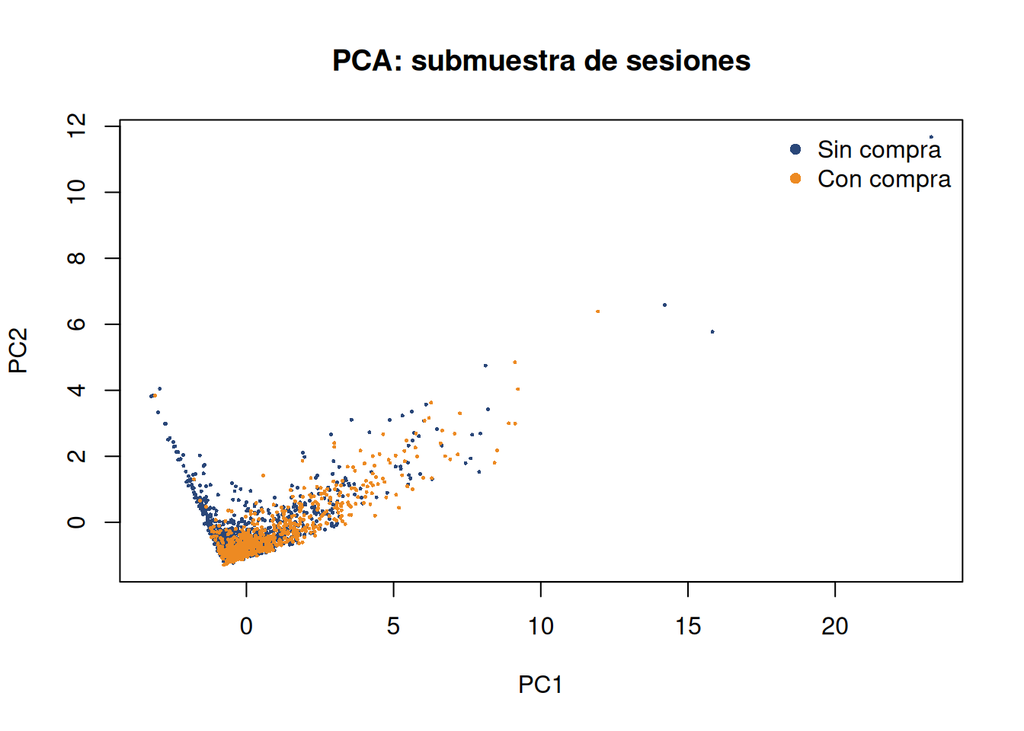

# 5. EDA orientado a hipótesis

```
     variable                media_compra media_no delta_cliff p_bilateral
[1,] ProductRelated          48.21        28.715   0.317       0
[2,] ProductRelated_Duration 1876.21      1069.988 0.346       0
[3,] BounceRates             0.005        0.025    -0.227      1.83e-61
[4,] ExitRates               0.02         0.047    -0.406      1.16e-175
```

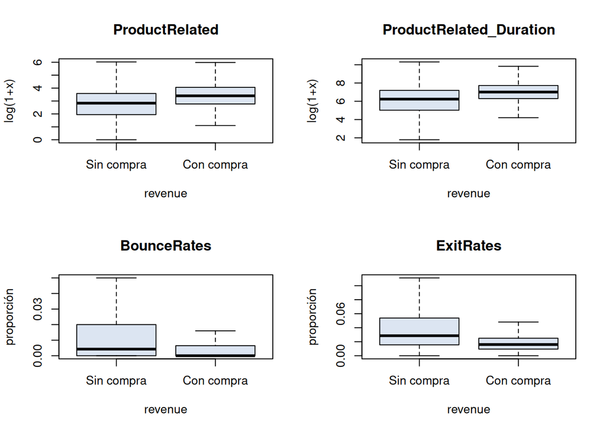

**H1:** Las métricas de productos son superiores entre sesiones con compra; apoyo exploratorio. **H2:** Las tasas de rebote y salida son inferiores; apoyo exploratorio. **H3:** Las correlaciones y componentes muestran redundancia parcial; apoyo exploratorio, no necesariamente reducción a dos ejes. Los contrastes son bilaterales y no confirmatorios (sin ajuste por multiplicidad). Diferencias y significación no establecen causalidad.

# 6. Hallazgos y decisiones para Unidad II

Respuesta: `Revenue`; predictoras originales y derivadas temporalmente disponibles. Tratar categorías como factores; analizar desbalance (15.5 % clase compra), atípicos, multicolinealidad y disponibilidad previa de `PageValues`. Separar datos antes de ajustar transformaciones; estandarización/PCA, imputación y selección deben estimarse dentro de cada fold. Comparar rendimiento con y sin PCA y reportar PR-AUC, ROC-AUC y sensibilidad. No se entrenan modelos definitivos en Unidad I.

# Referencia y declaración IA

Sakar, C. O., Polat, S. O., Katircioglu, M., & Kastro, Y. (2019). Real-time prediction of online shoppers’ purchasing intention using multilayer perceptron and LSTM recurrent neural networks. *Neural Computing and Applications, 31*, 6893–6908. https://doi.org/10.1007/s00521-018-3523-0.

UCI Machine Learning Repository (s. f.). *Online Shoppers Purchasing Intention Dataset*. https://doi.org/10.24432/C5F88Q.

**IA generativa:** ChatGPT (OpenAI) apoyó la redacción y la construcción del código. Deben verificarse la ejecución Quarto y la reproducción local en RStudio antes de presentar la entrega final.